# How much do we move during the day, and when?

The following is an examination of data from a personal fitness device, and contains the number of steps taken in five minute intervals of the day.

The data is contained in a csv file called “activity”, which is loaded as shown.

```r
data <- read.csv("activity.csv",header=TRUE,sep=",",quote="\"",dec=".",fill=TRUE,comment.char="")
```

The first question is to find the mean total number of steps taken per day (ignoring the missing values, NA, in the data set).

```r
stepsperday <- tapply(data$steps,data$date,sum)
mean(stepsperday,na.rm=TRUE)
```

```
## [1] 10766.19
```

```r
median(stepsperday,na.rm=TRUE)
```

```
## [1] 10765
```

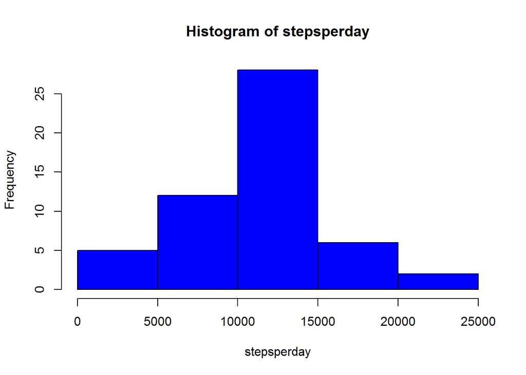

```r
hist(stepsperday,col="blue")
```

The next question is about the average daily activity pattern, which will be addressed by looking at the average number of steps taken in each time period of the day.

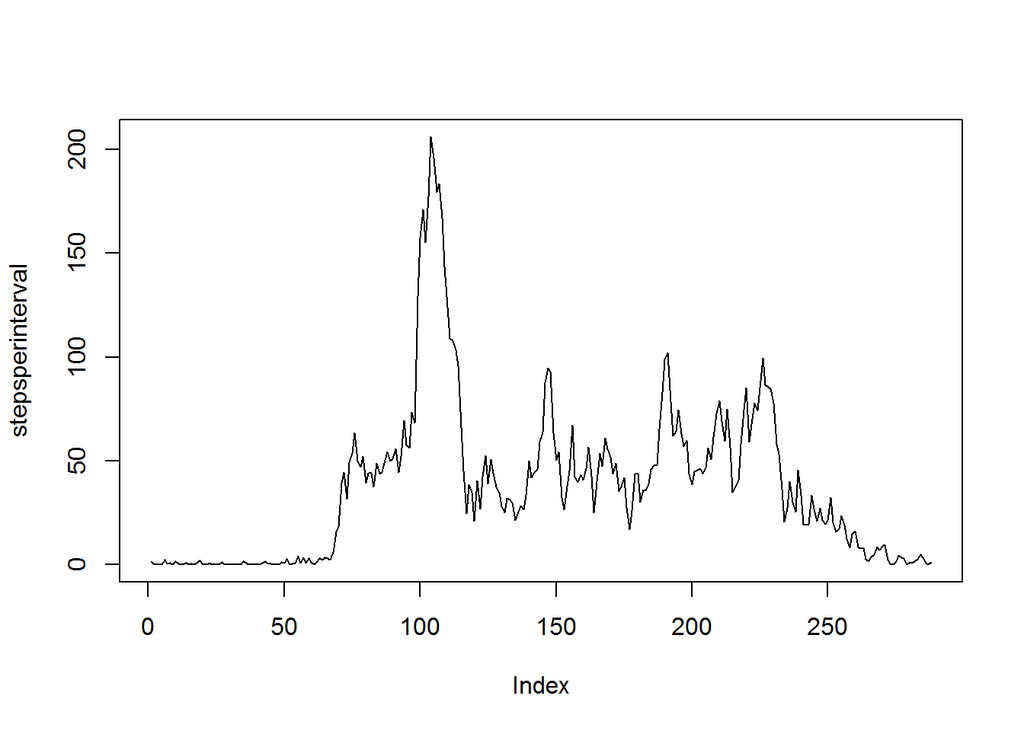

```r
stepsperinterval <- tapply(data$steps,data$interval,mean,na.rm=TRUE)
plot(stepsperinterval,type="l")
```

The 5-minute interval that contains the maximum number of steps on average across all the days in the dataset is:

```r
seq(along = stepsperinterval)[stepsperinterval == max(stepsperinterval)]
```

```
## [1] 104
```

There are a number of days/intervals where there are missing values (coded as NA). The presence of missing days may introduce bias into some calculations or summaries of the data.

The total number of missing values in the dataset (i.e. the total number of rows with NAs) is:

```r
sum(as.numeric(is.na(data$steps)))
```

```
## [1] 2304
```

Just to confirm the number of entries in the data set…

```r
unique(data$date)
```

```
##  [1] 2012-10-01 2012-10-02 2012-10-03 2012-10-04 2012-10-05 2012-10-06
##  [7] 2012-10-07 2012-10-08 2012-10-09 2012-10-10 2012-10-11 2012-10-12
## [13] 2012-10-13 2012-10-14 2012-10-15 2012-10-16 2012-10-17 2012-10-18
## [19] 2012-10-19 2012-10-20 2012-10-21 2012-10-22 2012-10-23 2012-10-24
## [25] 2012-10-25 2012-10-26 2012-10-27 2012-10-28 2012-10-29 2012-10-30
## [31] 2012-10-31 2012-11-01 2012-11-02 2012-11-03 2012-11-04 2012-11-05
## [37] 2012-11-06 2012-11-07 2012-11-08 2012-11-09 2012-11-10 2012-11-11
## [43] 2012-11-12 2012-11-13 2012-11-14 2012-11-15 2012-11-16 2012-11-17
## [49] 2012-11-18 2012-11-19 2012-11-20 2012-11-21 2012-11-22 2012-11-23
## [55] 2012-11-24 2012-11-25 2012-11-26 2012-11-27 2012-11-28 2012-11-29
## [61] 2012-11-30
## 61 Levels: 2012-10-01 2012-10-02 2012-10-03 2012-10-04 ... 2012-11-30
```

```r
avestepsperinterval <- as.vector(stepsperinterval)

avestepsperinterval <- rep(avestepsperinterval, 61)
avestepsperinterval[!is.na(data$steps)] = avestepsperinterval
tmp_dataTest <- as.vector(data$steps)
tmp_dataTest[is.na(tmp_dataTest)] = avestepsperinterval
```

```r
data_NoMissing <- data
data_NoMissing$steps <- avestepsperinterval * tmp_dataTest
stepsTotalPerDay_NoMissing <- tapply(data_NoMissing$steps, data_NoMissing$date,sum)
```

Below is a histogram of the total number of steps taken each day.

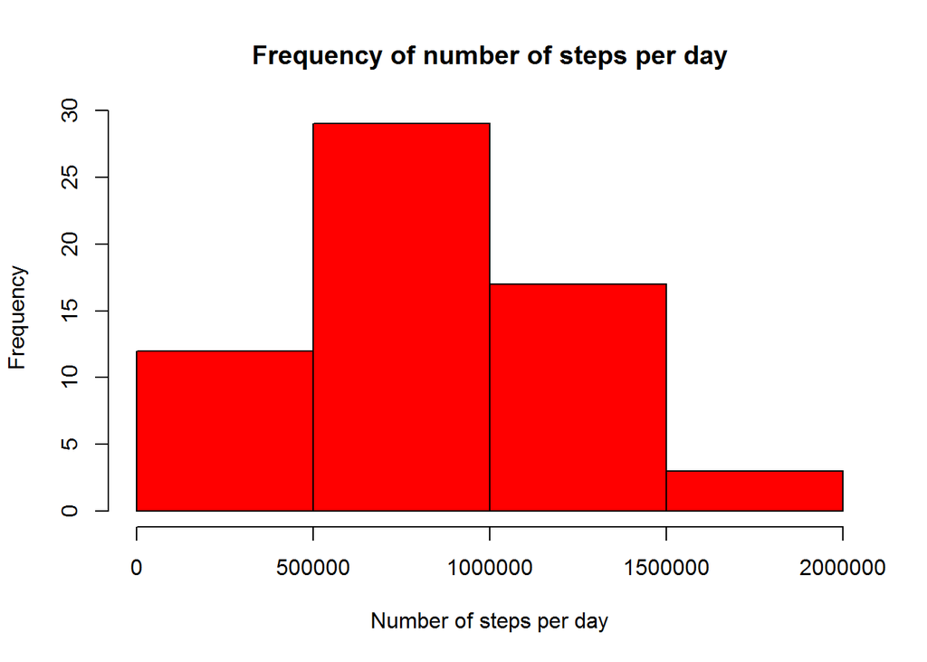

```r
hist(stepsTotalPerDay_NoMissing, breaks = 6, main = "Frequency of number of steps per day",xlab = "Number of steps per day", ylab = "Frequency", col = "red")
```

```r
mean(stepsTotalPerDay_NoMissing)
```

```
## [1] 831513.3
```

```r
median(stepsTotalPerDay_NoMissing)
```

```
## [1] 831513.3
```

Are there differences in activity patterns between weekdays and weekends?

A new factor variable is created in the dataset with two levels - “weekday” and “weekend” indicating whether a given date is a weekday or weekend day.

```r
data_NoMissing$date <- as.Date(strptime(data_NoMissing$date, format="%Y-%m-%d"))
data_NoMissing$day <- weekdays(data_NoMissing$date)
for (i in 1:nrow(data_NoMissing)) {
  if (data_NoMissing[i,]$day %in% c("Saturday","Sunday")) {
    data_NoMissing[i,]$day<-"weekend"
  }
  else{
    data_NoMissing[i,]$day<-"weekday"
  }
}
```

Next we make a panel plot containing a time series plot of the 5-minute interval (x-axis) and the average number of steps taken, averaged across all weekday days or weekend days (y-axis).

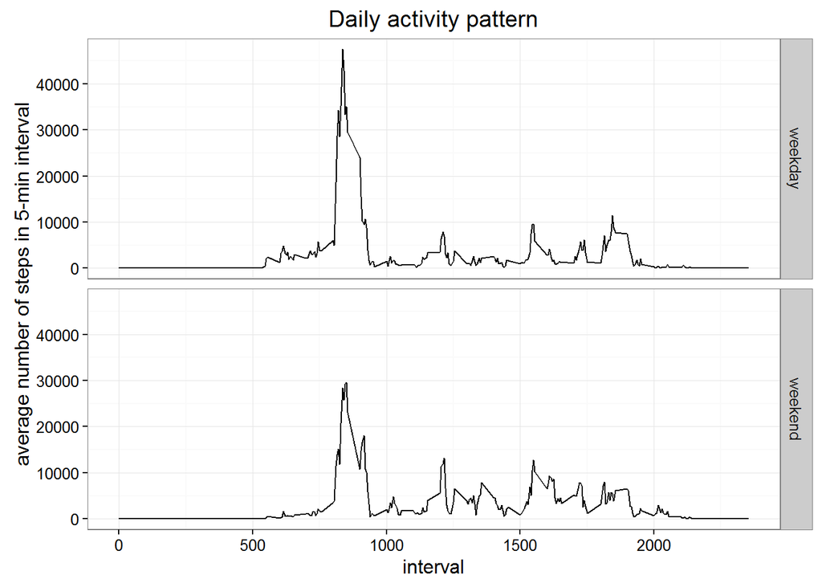

```r
week <- factor(weekdays(data_NoMissing$date) %in% c("Saturday","Sunday"),
               labels=c("weekday","weekend"), ordered=FALSE)

stepsByDay <- aggregate(data_NoMissing$steps, by=list(interval=data_NoMissing$interval, weekday=week), mean)

library(ggplot2)
g <- ggplot(stepsByDay,aes(interval,x))
g + geom_line() + facet_grid(weekday ~ .) +
    theme_bw() +
    labs(y="average number of steps in 5-min interval") +
    labs(x="interval") +
    labs(title="Daily activity pattern")
```